# IMC - TD n°2 : introduction à l’ACP avec `ade4`

Nicolas Derumigny

## Les données

```r
data(survey)
names(survey)
```

```
 [1] "Sex"    "Wr.Hnd" "NW.Hnd" "W.Hnd"  "Fold"   "Pulse"  "Clap"   "Exer"   "Smoke"
[10] "Height" "M.I"    "Age"
```

```r
survey.cc = survey[complete.cases(survey), ]
```

```r
help(survey)
```

`Wr.Hand` est la distance en cm de l’extrémité du pouce à l’extrémité de l’auriculaire de la main utilisée pour écrire. `NW.Hnd` correspond à la distance en cm de l’extrémité du pouce à l’extrémité de l’auriculaire de l’autre main. `Height`est la taille de l’étudiant en cm.

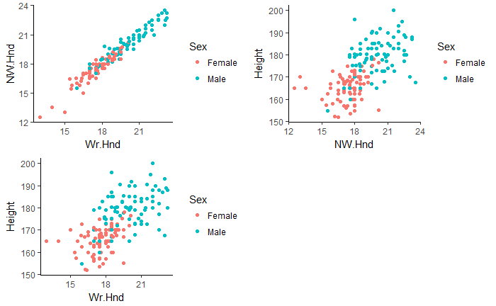

```r
theme_blank <-  theme_bw() + theme(panel.border = element_blank(), panel.grid.major = element_blank(),
panel.grid.minor = element_blank(), axis.line = element_line(colour = "black"))
work <- ggplot(survey.cc) + geom_point(aes(x = Wr.Hnd, y = NW.Hnd, color= Sex)) + theme_blank
work2 <- ggplot(survey.cc)  + geom_point(aes(x = Wr.Hnd, y = Height, color= Sex)) + theme_blank
work3 <- ggplot(survey.cc)  + geom_point(aes(x = NW.Hnd, y = Height, color= Sex)) + theme_blank
multiplot(work, work2, work3, cols = 2)
```

Les tailles des mains semblent fortement corrélées, ce qui est peu surprenant. De plus, les hommes ont des mains plus grandes que le femmes et sont globalement plus grands, ce qui est également logique. Enfin, la taille semble être corrélée avec la taille des mains (quelle que soit la main), bien que cela soit moins marquée que la corrélation main d’écriture/autre main.

## Centrage et réduction

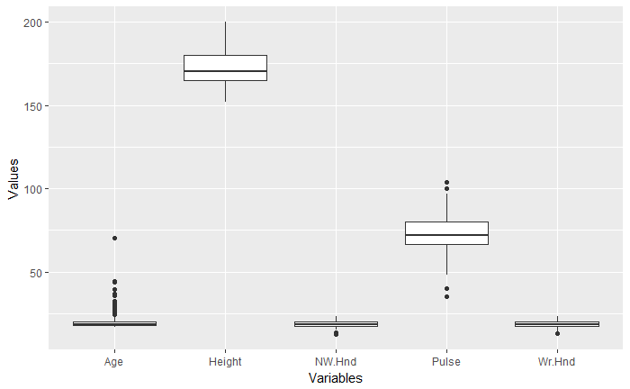

```r
survey.cc.g = survey.cc %>%  select(Wr.Hnd, NW.Hnd, Height, Age, Pulse) %>% gather(key = Variables, value = Values)
work <- ggplot(survey.cc.g) + geom_boxplot(aes(x = Variables, y = Values))
plot(work)
```

On remarque que `Age`, `NH.Hnd` et `Wr.Hnd` ont des distributions très similaires. A l’invers, rien n’est déductible de `Height` et `Pulse`.

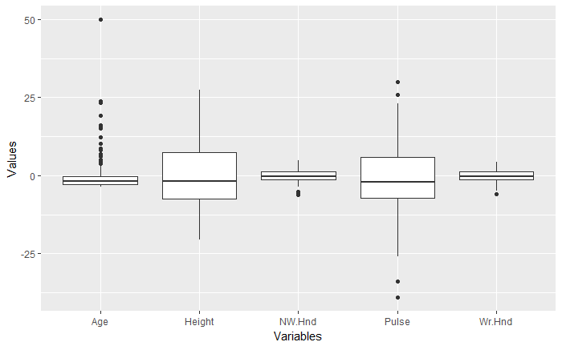

```r
survey.cc.center <- (survey.cc %>% select(Wr.Hnd, NW.Hnd, Height, Age, Pulse) %>% scale(center = TRUE, scale = FALSE))[,]
survey.cc.g <- as.data.frame(survey.cc.center) %>% gather(key = Variables, value = Values)
work <- ggplot(survey.cc.g) + geom_boxplot(aes(x = Variables, y = Values))
plot(work)
```

L’étalement des boxplots est très différent, ce qui n’est pas pratique pour les comparer.

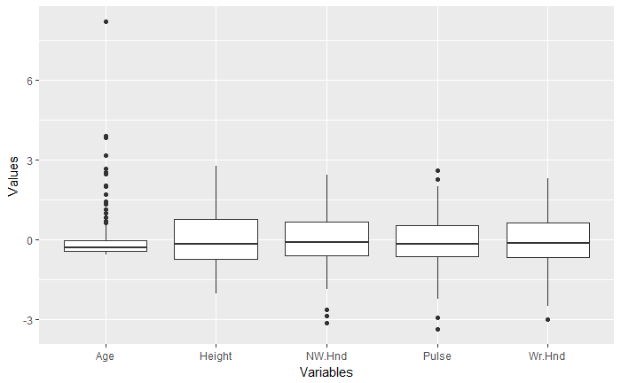

```r
survey.cc.center <- (survey.cc %>% select(Wr.Hnd, NW.Hnd, Height, Age, Pulse) %>% scale(center = TRUE, scale = TRUE))[,]
survey.cc.g <- as.data.frame(survey.cc.center) %>% gather(key = Variables, value = Values)
work <- ggplot(survey.cc.g) + geom_boxplot(aes(x = Variables, y = Values))
plot(work)
```

Ce graphe est davantage satisfaisant : on peut y voir la dispersion de la variable `Age` vers les valeures positives, alors que les autres variables semblent mieux réparties.

## ACP centrée réduite dans `ade4`

```r
survey.cc.numeric = survey.cc %>% select(Wr.Hnd, NW.Hnd, Pulse, Height, Age)
acp <- dudi.pca(survey.cc.numeric)
```

```
Select the number of axes:
```

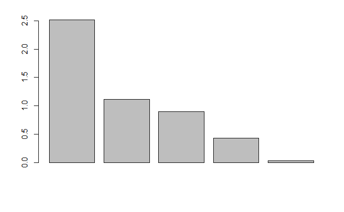

```r
3
```

```r
pve <- 100 * acp$eig/sum(acp$eig)
cumsum(pve)
```

```
[1]  50.38288  72.65099  90.68422  99.32002 100.00000
```

## ACP centrée réduite dans ade4

### Représentation des individus

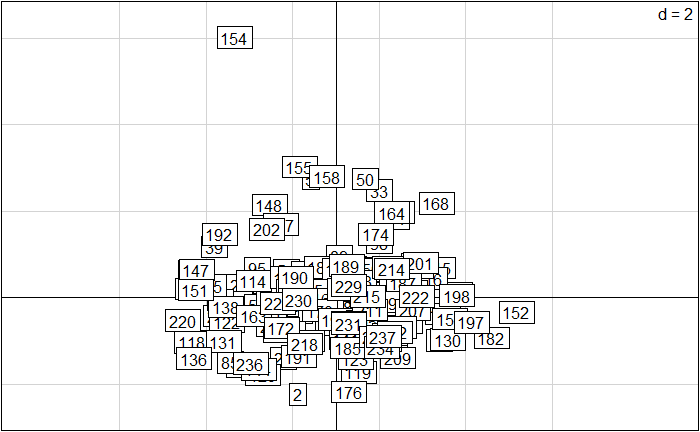

```r
s.label(acp$li, xax = 1, yax = 2)
```

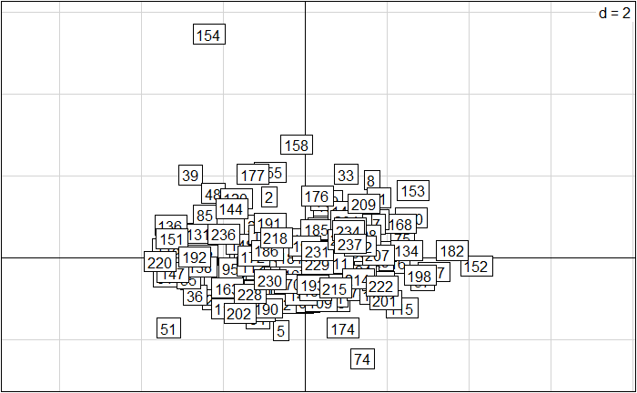

```r
s.label(acp$li, xax = 1, yax = 3)
```

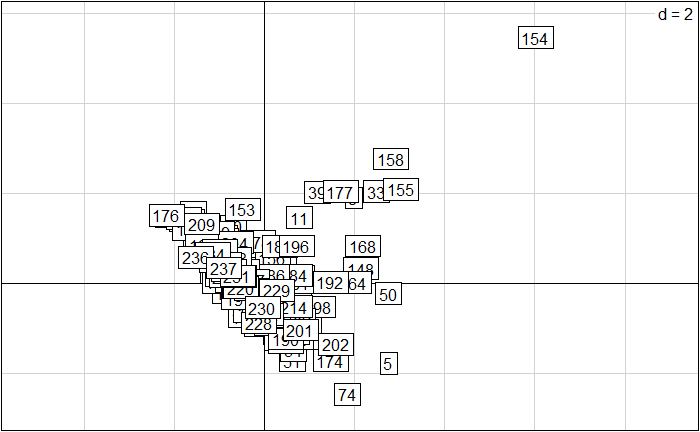

```r
s.label(acp$li, xax = 2, yax = 3)
```

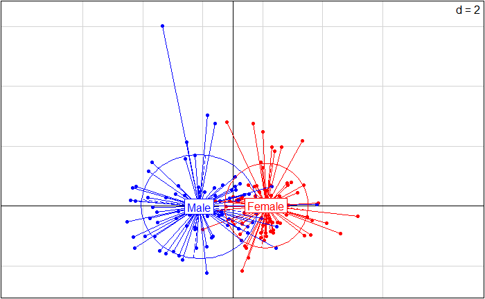

```r
s.class(dfxy = acp$li, fac = survey.cc$Sex, col = c("red", "blue"), xax = 1, yax = 2)
```

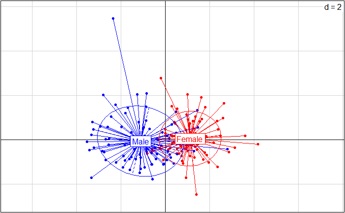

```r
s.class(dfxy = acp$li, fac = survey.cc$Sex, col = c("red", "blue"), xax = 1, yax = 3)
```

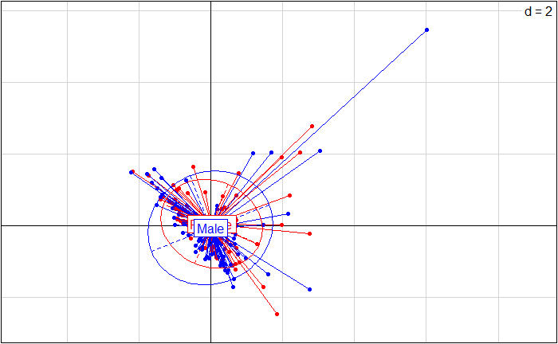

```r
s.class(dfxy = acp$li, fac = survey.cc$Sex, col = c("red", "blue"), xax = 2, yax = 3)
```

### Représentation des variables

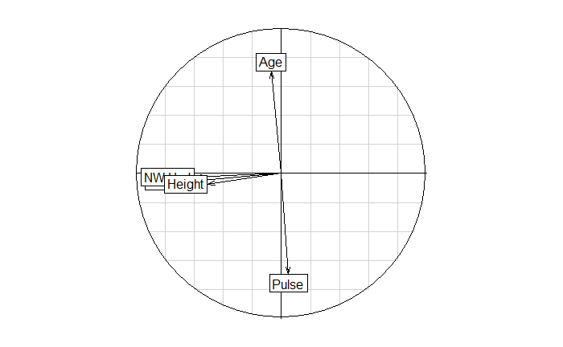

```r
s.corcircle(dfxy = acp$c1)
```

11. On remarque que les tailles des mains sont très corrélées entre elles et avec la taille de l’individu. A l’inverse, le rythme cardiaque comme l’age ne semble pas jouer de rôle pour aucune de ces données. Par contre, le rythme cardaique est très fortement négativement corrélé à l’age : plus l’étudiant est agé et moin son pouls est bas, ce qui est logique.

```r
scatter(acp, clab.row = 0, posieig = "none")
```

```r
s.class(acp$li, survey.cc$Sex, col = c("red", "blue"), add.plot = TRUE, cstar = 0,
clabel = 0, cellipse = 0)
```

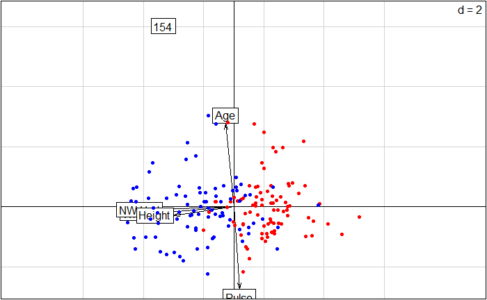

```r
s.label(acp$li[106,], clab=1, add.p=T)
```

## Contribution à l’inertie

```r
inertia.dudi(acp)
```

```
Inertia information:
Call: inertia.dudi(x = acp)

Decomposition of total inertia:
    inertia     cum  cum(%)
Ax1  2.5191   2.519   50.38
Ax2  1.1134   3.633   72.65
Ax3  0.9017   4.534   90.68
Ax4  0.4318   4.966   99.32
Ax5  0.0340   5.000  100.00
```

```r
inertia.dudi(acp, col.inertia = TRUE)
```

```
Inertia information:
Call: inertia.dudi(x = acp, col.inertia = TRUE)

Decomposition of total inertia:
    inertia     cum  cum(%)
Ax1  2.5191   2.519   50.38
Ax2  1.1134   3.633   72.65
Ax3  0.9017   4.534   90.68
Ax4  0.4318   4.966   99.32
Ax5  0.0340   5.000  100.00

Column contributions (%):
 Wr.Hnd  NW.Hnd   Pulse  Height     Age
     20      20      20      20      20

Column absolute contributions (%):
       Axis1(%) Axis2(%) Axis3(%)
Wr.Hnd  36.7607  0.27721   0.3952
NW.Hnd  36.3587  0.05994   0.7150
Pulse    0.2353 48.87288  48.9899
Height  26.1435  0.53624   4.0665
Age      0.5018 50.25373  45.8333

Signed column relative contributions:
          Axis1     Axis2   Axis3
Wr.Hnd -92.6055  -0.30864  0.3563
NW.Hnd -91.5929  -0.06674  0.6447
Pulse    0.5928 -54.41533 44.1723
Height -65.8592  -0.59705 -3.6666
Age     -1.2641  55.95278 41.3261

Cumulative sum of column relative contributions (%):
         Axis1 Axis1:2 Axis1:3 Axis4:5
Wr.Hnd 92.6055   92.91   93.27  6.7295
NW.Hnd 91.5929   91.66   92.30  7.6956
Pulse   0.5928   55.01   99.18  0.8196
Height 65.8592   66.46   70.12 29.8771
Age     1.2641   57.22   98.54  1.4570
```

```r
inertia.dudi(acp, row.inertia = TRUE)
```

```
Inertia information:
Call: inertia.dudi(x = acp, row.inertia = TRUE)

Decomposition of total inertia:
    inertia     cum  cum(%)
Ax1  2.5191   2.519   50.38
Ax2  1.1134   3.633   72.65
Ax3  0.9017   4.534   90.68
Ax4  0.4318   4.966   99.32
Ax5  0.0340   5.000  100.00

Row contributions (%):
      1       2       5       6       7       8       9      10      11      14      17
0.32578 0.98047 1.56718 0.14504 0.28354 1.22102 0.08272 0.28207 0.73895 0.53628 0.53220
     18      20      21      22      23      24      27      28      30      32      33
```

[output cut: 542 more lines]

De manière peu surprenante, l’axe 1 est dû principalement aux variable de taille (mains et individus). Le deuxième et le troisieme axe sont tous deux composé prinicpalement du rythme cardiaque et de l’age, ce qui est à nouveau peu surprenant. En ragardant les contributions relatives signées, le rythme cardiaque suit le signe inverse du poul sur l’axe secondaire, mais le même signe sur le troisième axe, d’oùu la nexessité de séectionner trois axes pour obtenir une reconstruction de l’information suffisante. L’individu 154 se démarque fortement des autres par sa contribution comme ligne (8.5 contre une valeur entre 0.1 et 2 pour le reste du groupe), ce que l’on avait déjà constaté sur les représentations graphiques (position très excentrée). En regardants les contribution absolues, elle contribue majoritairement aux axes 2 et 3.

# Exercice en autonomie

```r
data(deug)
summary(deug$result)
```

```
 D  A A+ C- B-  B
11 17  2 20  2 52
```

(Est-ce vraiment la réponse ?????) Les notes vont de D à A+.

(Comment valident-on ? Personbellement, je valide à 12/20 avec compensation des matières si la note est plus grande que 7). En supposant qu’il faille une moyenne gloable supérieure ou égale à 10 pour valider, il suffit que la somme des notes soit plus grande que la somme des notes minimales pour valider (car tout est coefficienté). En suivant cette méthode, 65 élèves valident.

3.Les coefficients de chaque matière sont

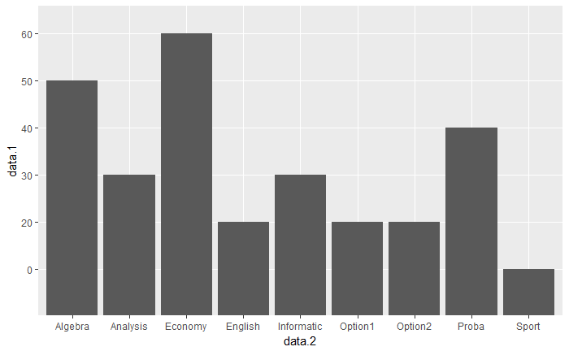

```r
data_frame_cause_r_is_annoying_with_data_structures <- data.frame(
  data=cbind(as.vector(deug$cent), names(deug$cent)))
work <- ggplot(data_frame_cause_r_is_annoying_with_data_structures) + aes(x=data.2, y=data.1) + geom_col()
plot(work)
```

4. Il s’agit probablement d’une license mention mathématique du parcours mathématique et économie (cf http://licence-math.univ-lyon1.fr/lib/exe/fetch.php?media=schema_math_eco.pdf)

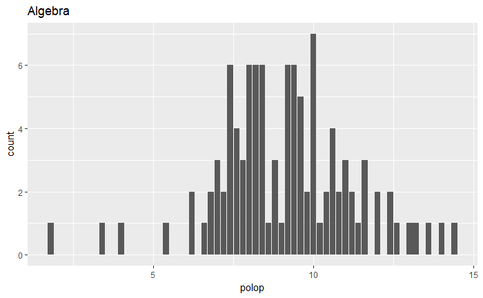

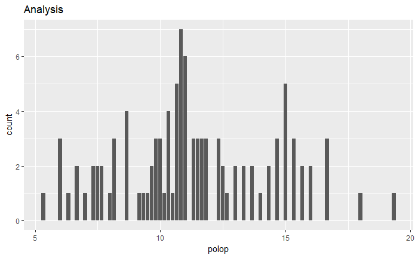

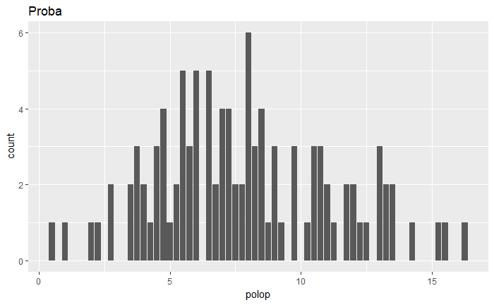

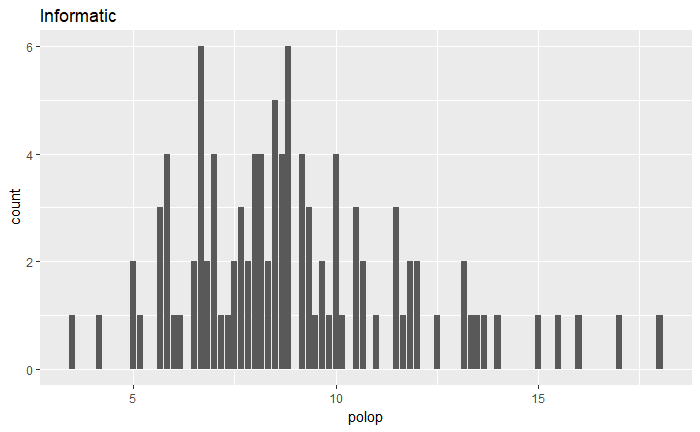

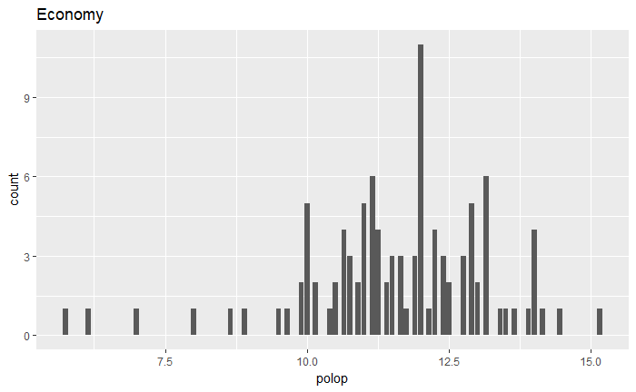

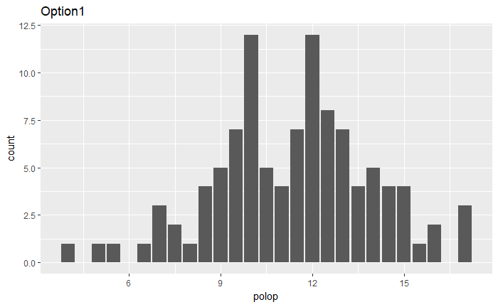

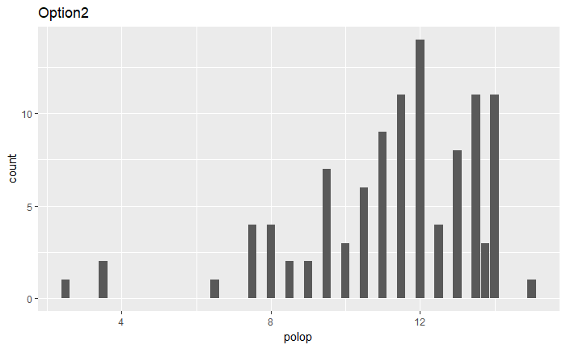

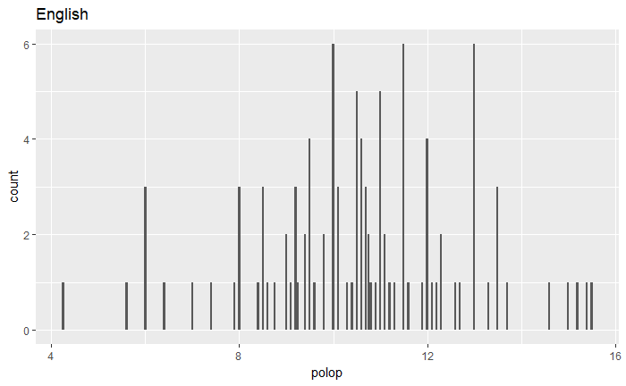

```r
for (i in 1:8)
{
  data_work <- data.frame(polop = deug$tab[,i]/deug$cent[i]*10)
  work <- ggplot(data=data_work) + aes(x=polop) + geom_bar() + ggtitle(names(deug$cent)[i])
  plot(work)
}
```

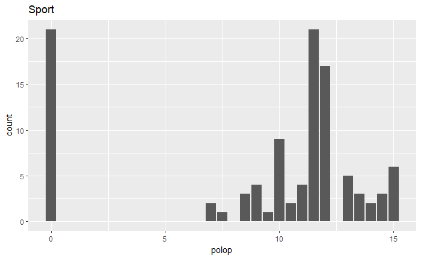

```r
data_work <- data.frame(polop = deug$tab[,9])
work <- ggplot(data=data_work) + aes(x=polop) + geom_bar() + ggtitle(names(deug$cent)[9])
plot(work)
```

Les matières les plus difficiles sont informatiques et probabilité. Si je n’avais qu’une seule matière à réviser, ce serait l’économie car elle a le plus haut coefficient.

```r
names(deug$cent)[which.max(deug$cent)]
```

```
[1] "Economy"
```

```r
pca <- dudi.pca(deug$tab, col.w = deug$cent/sum(deug$cent))
```

```
Select the number of axes:
```

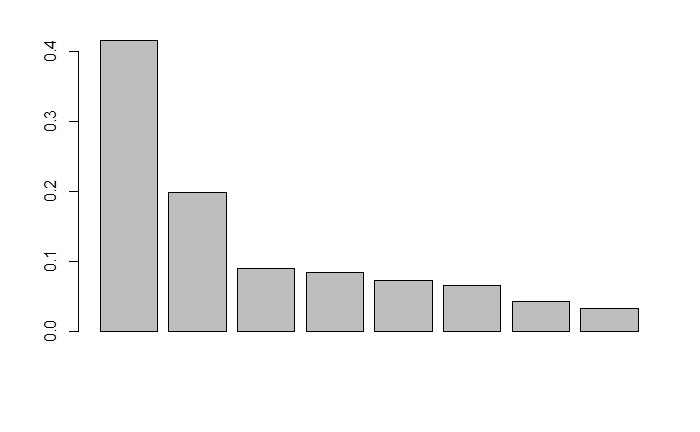

```r
3
```

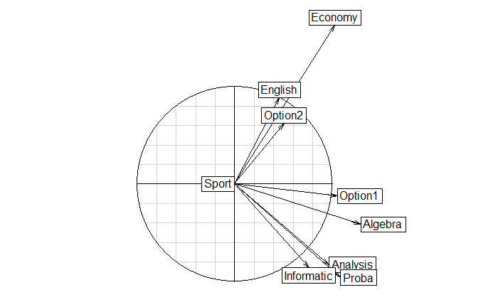

```r
s.corcircle(dfxy = pca$c1)
```

Le premier axe représente les bons élèves contre les mauvais, le second resprésente les littéraires contre les scientifiques.

```r
pca <- dudi.pca(deug$tab)
```

```
Select the number of axes:
```

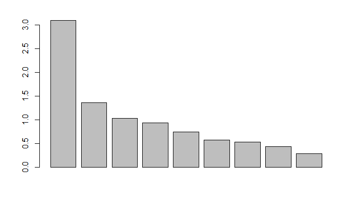

```r
3
```

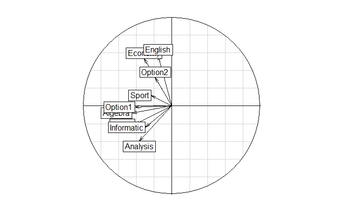

```r
s.corcircle(dfxy = pca$c1)
```

Les variables sont toutes dans le cercle, ce qui est plus logique au vu de la définition donnée (problèle au niveau des coefficients ?). De plus, on prends en compte le sport, qui était auparavant nul (coefficient de zero).